# Fase 3. Análisis estadístico: programa de fidelización de Elite Retail

Métodos y Programas Estadísticos para Ciencia de Datos IV — Proyecto Integrador 4to Semestre LCD

GRUPO 2

12/11/2026

# 1 Introducción

## 1.1 Problema y objetivo (Fase 1)

**Problema.** El programa de fidelización de Elite Retail clasifica a los clientes en cuatro niveles (Bronze, Silver, Gold y Platinum), pero esos niveles **no reflejan diferencias en el comportamiento de compra**. Por eso es difícil saber qué clientes generan más valor y hacia quiénes dirigir los beneficios.

**Objetivo.** Segmentar a los 100,000 clientes con sus compras de 2025, identificar al **20% de clientes con mayor gasto** y proponer una clasificación para asignar los beneficios según el valor comercial. **KPI principal:** participación en ventas del 20% de clientes con mayor gasto (línea base: ≈ 31%).

## 1.2 Los tres métodos estadísticos elegidos y por qué

| # | Método | Pregunta que responde | Objetivo de la Fase 1 |
| --- | --- | --- | --- |
| 1 | **ANOVA de una vía** (con Kruskal-Wallis y Welch como respaldo) | ¿Gastan distinto los clientes de los cuatro niveles? | Obj. 2 y Escenario 1 |
| 2 | **Prueba chi-cuadrado de independencia** (con V de Cramér) | ¿El nivel actual predice quién es un cliente de alto gasto? Y: ¿quien es de alto gasto en un periodo lo sigue siendo en el siguiente? | Obj. 3 y 4, Escenarios 1 y 2 |
| 3 | **Análisis de concentración**: curva de Lorenz, coeficiente de Gini e intervalo de confianza bootstrap | ¿Qué tan concentradas están las ventas en pocos clientes? ¿Cuánto pesa el 20% que más gasta? | Obj. 3 y KPI principal |

Estos tres métodos cubren el problema completo: el **1** evalúa la clasificación actual, el **3** mide el valor del grupo de mayor gasto y el **2** comprueba si cualquier clasificación (actual o propuesta) sirve para orientar beneficios. No se usan otros métodos (regresión, k-means, series de tiempo) porque la Fase 1 no los requiere: el criterio de clasificación definido es el gasto anual.

## 1.3 Guía rápida para leer los resultados

- **Valor p:** si es menor a 0.05, la diferencia observada *probablemente no es casualidad*. Si es mayor, *no hay evidencia de diferencia*.
- **Tamaño del efecto** (eta², V de Cramér): dice *qué tan grande* es la diferencia. Cerca de 0 = no importa.
- **Gini:** mide la desigualdad del gasto: 0 = todos gastan igual; 1 = un solo cliente gasta todo.
- **Intervalo de confianza (IC) al 95%:** rango dentro del cual está, con alta probabilidad, el valor real.

> **Aviso.** Los datos parecen ser sintéticos (generados para un ejercicio académico). Los resultados se presentan como conclusiones **de este conjunto de datos**, no como hechos comprobados de una empresa real.

# 2 Datos y preparación

```r
ruta <- "proyecto_integrador"
leer <- function(f) data.table::fread(file.path(ruta, f)) %>% as_tibble()

ventas    <- leer("sales_raw_oltp.csv")
clientes  <- leer("customers_master.csv")
productos <- leer("products_catalog.csv")

# El importe de la venta no viene en la tabla: = cantidad × precio de lista del catálogo
ventas <- ventas %>%
  mutate(event_time = as.POSIXct(as.character(event_time), tz = "UTC", format = "%Y-%m-%d %H:%M:%OS"),
         fecha = as_date(event_time)) %>%
  left_join(productos %>% select(product_id, retail_price), by = "product_id") %>%
  mutate(importe = quantity * retail_price,
         semestre = ifelse(fecha < as.Date("2025-07-01"), "S1", "S2"))

tibble(control = c("Transacciones", "Clientes en el maestro", "Valores nulos en ventas",
                   "Ventas con cliente inexistente", "Ventas con producto inexistente",
                   "Periodo de las ventas"),
       resultado = c(comma(nrow(ventas)), comma(nrow(clientes)), sum(is.na(ventas)),
                     sum(!ventas$customer_id %in% clientes$customer_id),
                     sum(!ventas$product_id %in% productos$product_id),
                     paste(min(ventas$fecha), "a", max(ventas$fecha)))) %>%
  kable(caption = "Controles de calidad")
```

Controles de calidad

| control | resultado |
| --- | --- |
| Transacciones | 1,000,000 |
| Clientes en el maestro | 100,000 |
| Valores nulos en ventas | 0 |
| Ventas con cliente inexistente | 0 |
| Ventas con producto inexistente | 0 |
| Periodo de las ventas | 2025-01-01 a 2025-12-30 |

## 2.1 Gasto anual por cliente

Se calcula el **gasto anual de cada cliente** (suma de sus compras de 2025). Se incluyen los 100,000 clientes del maestro; los pocos que no compraron quedan con gasto 0.

```r
gasto <- ventas %>% group_by(customer_id) %>%
  summarise(gasto = sum(importe), compras = n(), unidades = sum(quantity),
            gasto_s1 = sum(importe[semestre == "S1"]),
            gasto_s2 = sum(importe[semestre == "S2"]), .groups = "drop")

cli <- clientes %>%
  transmute(customer_id, nivel_actual = factor(loyalty_tier, levels = c("Bronze","Silver","Gold","Platinum"))) %>%
  left_join(gasto, by = "customer_id") %>%
  mutate(across(c(gasto, compras, unidades, gasto_s1, gasto_s2), ~ replace_na(.x, 0)),
         ticket = ifelse(compras > 0, gasto / compras, NA_real_))

N <- nrow(cli); k20 <- N * 0.20
cli <- cli %>% mutate(
  top20    = rank(-gasto,    ties.method = "first") <= k20,   # 20% de mayor gasto en el año
  top20_s1 = rank(-gasto_s1, ties.method = "first") <= k20,   # ... en el primer semestre
  top20_s2 = rank(-gasto_s2, ties.method = "first") <= k20)   # ... en el segundo semestre

ventas_totales <- sum(cli$gasto)

tibble(indicador = c("Clientes", "Clientes sin compras", "Ventas totales 2025", "Gasto medio por cliente",
                     "Gasto mediano", "Gasto mínimo", "Gasto máximo"),
       valor = c(comma(N), sum(cli$gasto == 0), comma(ventas_totales, 1), comma(mean(cli$gasto), 1),
                 comma(median(cli$gasto), 1), comma(min(cli$gasto), 1), comma(max(cli$gasto), 1))) %>%
  kable(caption = "Resumen del gasto anual por cliente")
```

Resumen del gasto anual por cliente

| indicador | valor |
| --- | --- |
| Clientes | 100,000 |
| Clientes sin compras | 4 |
| Ventas totales 2025 | 8,621,562,381 |
| Gasto medio por cliente | 86,216 |
| Gasto mediano | 83,713 |
| Gasto mínimo | 0 |
| Gasto máximo | 281,963 |

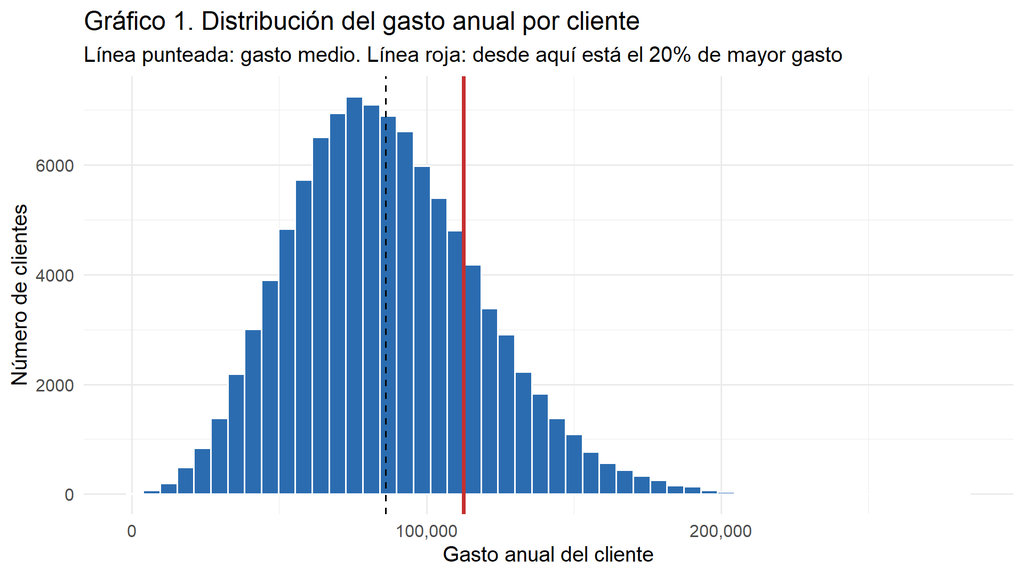

```r
umbral <- min(cli$gasto[cli$top20])
ggplot(cli %>% filter(gasto > 0), aes(gasto)) +
  geom_histogram(bins = 50, fill = azul, color = "white") +
  geom_vline(xintercept = mean(cli$gasto), color = "black", linetype = "dashed") +
  geom_vline(xintercept = umbral, color = rojo, linewidth = 1) +
  scale_x_continuous(labels = comma) +
  labs(title = "Gráfico 1. Distribución del gasto anual por cliente",
       subtitle = "Línea punteada: gasto medio. Línea roja: desde aquí está el 20% de mayor gasto",
       x = "Gasto anual del cliente", y = "Número de clientes")
```

> **Cómo leerlo.** Cada barra cuenta cuántos clientes gastaron una cantidad parecida en el año. La línea roja separa al 20% que más gastó (a su derecha) del resto.

# 3 Método 1: ANOVA de una vía. ¿Gastan distinto los niveles de fidelización?

**Idea simple.** El ANOVA compara el gasto promedio de varios grupos y pregunta si las diferencias que se ven son reales o producto del azar. **H₀:** los cuatro niveles gastan en promedio lo mismo. Es la prueba del Escenario 1 (clasificación actual).

```r
cli %>% group_by(nivel_actual) %>%
  summarise(clientes = n(), gasto_medio = mean(gasto), gasto_mediano = median(gasto),
            desv_est = sd(gasto), compras_medias = mean(compras),
            ticket_medio = mean(ticket, na.rm = TRUE), .groups = "drop") %>%
  kable(digits = 1, format.args = list(big.mark = ","), caption = "Gasto y comportamiento por nivel de fidelización")
```

Gasto y comportamiento por nivel de fidelización

| nivel_actual | clientes | gasto_medio | gasto_mediano | desv_est | compras_medias | ticket_medio |
| --- | --- | --- | --- | --- | --- | --- |
| Bronze | 24,961 | 86,089.0 | 83,623.4 | 32,030.5 | 10 | 8,624.3 |
| Silver | 25,029 | 86,402.5 | 83,831.0 | 32,246.3 | 10 | 8,613.8 |
| Gold | 25,084 | 86,240.7 | 83,693.8 | 32,142.8 | 10 | 8,619.5 |
| Platinum | 24,926 | 86,129.6 | 83,687.8 | 32,097.0 | 10 | 8,635.3 |

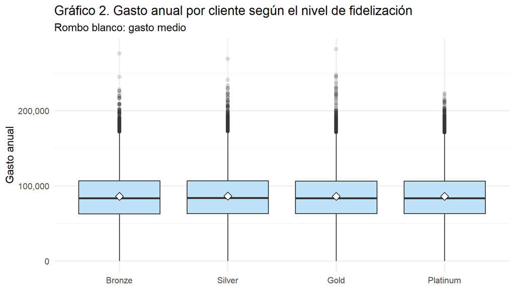

```r
ggplot(cli, aes(nivel_actual, gasto)) +
  geom_boxplot(fill = "#bee3f8", outlier.alpha = .15) +
  stat_summary(fun = mean, geom = "point", shape = 23, fill = "white", size = 3) +
  scale_y_continuous(labels = comma) +
  labs(title = "Gráfico 2. Gasto anual por cliente según el nivel de fidelización",
       subtitle = "Rombo blanco: gasto medio", x = NULL, y = "Gasto anual")
```

> **Cómo leerlo.** Cada caja resume a los clientes de un nivel: la línea central es el cliente típico (mediana) y la caja contiene a la mitad central de sus clientes. Si el programa funcionara, las cajas de Silver, Gold y Platinum estarían cada vez más arriba.

> **Qué significa para Elite Retail.** Las cuatro cajas están **a la misma altura**: la mediana ronda los 83,700 en todos los niveles y la media va de 86,089 (Bronze) a 86,402 (Silver), una diferencia de **0.4%**. Un cliente Platinum gasta lo mismo que uno Bronze. Esto confirma, con datos, el problema planteado en la Fase 1.

```r
m_aov <- aov(gasto ~ nivel_actual, data = cli)
tab <- tidy(m_aov)
tab %>% kable(digits = 5, caption = "Tabla ANOVA: gasto anual según nivel de fidelización")
```

Tabla ANOVA: gasto anual según nivel de fidelización

| term | df | sumsq | meansq | statistic | p.value |
| --- | --- | --- | --- | --- | --- |
| nivel_actual | 3 | 1474207907 | 491402636 | 0.47603 | 0.69896 |
| Residuals | 99996 | 103225270041443 | 1032293992 | NA | NA |

```r
ss <- tab$sumsq
cat("eta cuadrado =", format(ss[1] / sum(ss), digits = 3), "\n\n")
```

```
## eta cuadrado = 0.0000143
```

```r
oneway.test(gasto ~ nivel_actual, data = cli)      # ANOVA de Welch (no asume varianzas iguales)
```

```
##
##  One-way analysis of means (not assuming equal variances)
##
## data:  gasto and nivel_actual
## F = 0.47488, num df = 3, denom df = 55553, p-value = 0.6998
```

```r
kruskal.test(gasto ~ nivel_actual, data = cli)     # prueba no paramétrica (no asume normalidad)
```

```
##
##  Kruskal-Wallis rank sum test
##
## data:  gasto by nivel_actual
## Kruskal-Wallis chi-squared = 1.0053, df = 3, p-value = 0.8
```

```r
# ¿Cambia la conclusión si en vez del gasto miramos sus dos componentes?
comparar <- function(var, etiqueta) {
  t <- tidy(aov(as.formula(paste(var, "~ nivel_actual")), data = cli))
  tibble(variable = etiqueta, F = round(t$statistic[1], 2), valor_p = round(t$p.value[1], 3))
}
bind_rows(comparar("gasto", "Gasto anual"), comparar("compras", "Número de compras"),
          comparar("ticket", "Gasto por compra (ticket)")) %>%
  mutate(conclusion = ifelse(valor_p < 0.05, "Hay diferencia", "No hay diferencia")) %>%
  kable(caption = "ANOVA para el gasto y sus componentes")
```

ANOVA para el gasto y sus componentes

| variable | F | valor_p | conclusion |
| --- | --- | --- | --- |
| Gasto anual | 0.48 | 0.699 | No hay diferencia |
| Número de compras | 1.67 | 0.172 | No hay diferencia |
| Gasto por compra (ticket) | 0.63 | 0.597 | No hay diferencia |

# 4 Método 2: Chi-cuadrado de independencia. ¿Sirve una clasificación para encontrar a los clientes de alto valor?

**Idea simple.** La prueba chi-cuadrado revisa si dos categorías están relacionadas. Aquí las usamos de dos formas: **(a)** ¿el nivel actual está relacionado con ser del 20% de mayor gasto? y **(b)** ¿ser del 20% de mayor gasto en un periodo está relacionado con serlo en el siguiente? La segunda pregunta es la que dice si una clasificación por gasto **sirve para decidir beneficios a futuro**.

## 4.1 (a) Nivel actual vs. pertenecer al 20% de mayor gasto

```r
cramer_v <- function(tab) {
  chi <- suppressWarnings(chisq.test(tab, correct = FALSE))$statistic
  unname(sqrt(chi / (sum(tab) * (min(dim(tab)) - 1))))
}

tab_a <- table(cli$nivel_actual, cli$top20, dnn = c("Nivel", "Top 20%"))
tab_a
```

```
##           Top 20%
## Nivel      FALSE  TRUE
##   Bronze   19995  4966
##   Silver   19985  5044
##   Gold     20042  5042
##   Platinum 19978  4948
```

```r
chisq.test(tab_a)
```

```
##
##  Pearson's Chi-squared test
##
## data:  tab_a
## X-squared = 1.0415, df = 3, p-value = 0.7912
```

```r
cat("V de Cramér =", round(cramer_v(tab_a), 4), "\n")
```

```
## V de Cramér = 0.0032
```

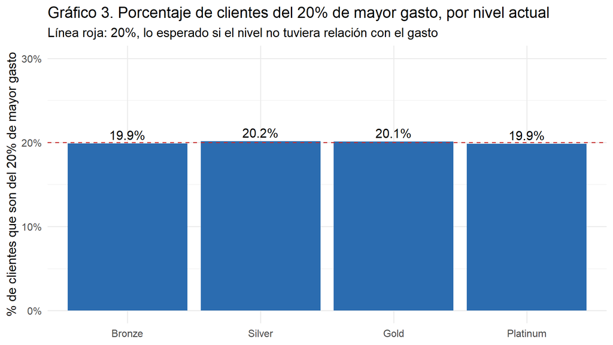

```r
tasa_a <- cli %>% group_by(nivel_actual) %>%
  summarise(clientes = n(), en_top20 = sum(top20), porcentaje = mean(top20), .groups = "drop")

ggplot(tasa_a, aes(nivel_actual, porcentaje)) +
  geom_col(fill = azul) +
  geom_hline(yintercept = 0.20, linetype = "dashed", color = rojo) +
  geom_text(aes(label = percent(porcentaje, 0.1)), vjust = -0.4) +
  scale_y_continuous(labels = percent, limits = c(0, 0.30)) +
  labs(title = "Gráfico 3. Porcentaje de clientes del 20% de mayor gasto, por nivel actual",
       subtitle = "Línea roja: 20%, lo esperado si el nivel no tuviera relación con el gasto",
       x = NULL, y = "% de clientes que son del 20% de mayor gasto")
```

> **Cómo leerlo.** Cada barra indica qué porcentaje de los clientes de ese nivel está entre los que más gastan. Si el programa identificara bien a los clientes valiosos, la barra de Platinum sería mucho más alta que la de Bronze. La línea roja (20%) es lo que pasaría por pura casualidad.

> **Qué significa para Elite Retail.** Las cuatro barras están **pegadas a la línea roja**: 19.9% en Bronze y en Platinum, 20.1% en Gold y 20.2% en Silver. Solo **4,948 de los 24,926 clientes Platinum** están en el 20% que más gasta; en Bronze son 4,966. La prueba da χ² = 1.04, **p = 0.79** y V de Cramér = 0.003 (relación nula). **Ser Platinum no aumenta la probabilidad de ser un cliente de alto gasto.** Es el mismo resultado del Método 1 desde otro ángulo, y muestra que los beneficios actuales no están llegando de forma preferente a los mejores clientes.

## 4.2 (b) ¿Es persistente el alto gasto? Primer semestre vs. segundo semestre

Para que una clasificación por gasto sirva para repartir beneficios, los clientes que gastan mucho hoy deberían seguir gastando mucho después. Se divide 2025 en dos semestres: ¿los del 20% de mayor gasto en enero-junio vuelven a estar en el 20% de mayor gasto en julio-diciembre?

```r
tab_b <- table(`Top 20% en S1 (ene-jun)` = cli$top20_s1, `Top 20% en S2 (jul-dic)` = cli$top20_s2)
tab_b
```

```
##                        Top 20% en S2 (jul-dic)
## Top 20% en S1 (ene-jun) FALSE  TRUE
##                   FALSE 63963 16037
##                   TRUE  16037  3963
```

```r
chisq.test(tab_b)
```

```
##
##  Pearson's Chi-squared test with Yates' continuity correction
##
## data:  tab_b
## X-squared = 0.52041, df = 1, p-value = 0.4707
```

```r
cat("V de Cramér =", round(cramer_v(tab_b), 4), "\n\n")
```

```
## V de Cramér = 0.0023
```

```r
cor.test(cli$gasto_s1, cli$gasto_s2)
```

```
##
##  Pearson's product-moment correlation
##
## data:  cli$gasto_s1 and cli$gasto_s2
## t = -0.21549, df = 99998, p-value = 0.8294
## alternative hypothesis: true correlation is not equal to 0
## 95 percent confidence interval:
##  -0.006879394  0.005516528
## sample estimates:
##           cor
## -0.0006814589
```

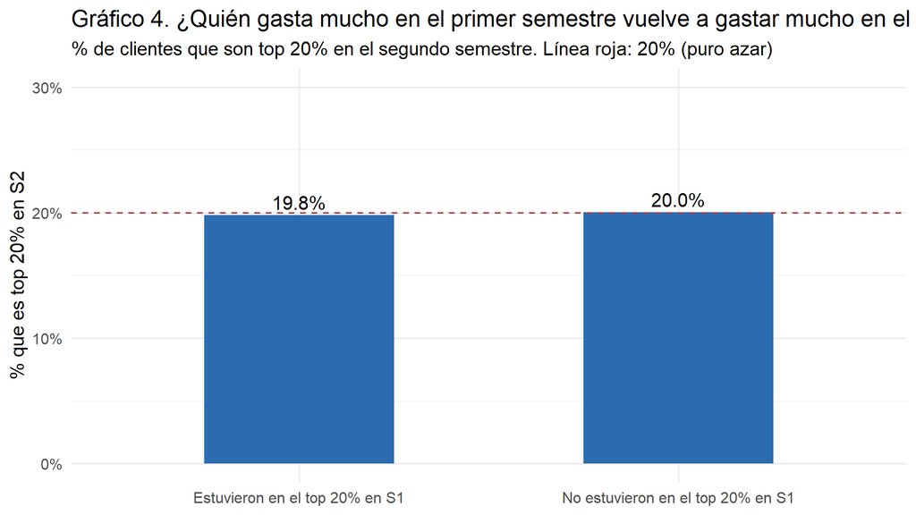

```r
persist <- tibble(
  grupo = c("Estuvieron en el top 20% en S1", "No estuvieron en el top 20% en S1"),
  porcentaje = c(mean(cli$top20_s2[cli$top20_s1]), mean(cli$top20_s2[!cli$top20_s1])))

ggplot(persist, aes(grupo, porcentaje)) +
  geom_col(fill = azul, width = .5) +
  geom_hline(yintercept = 0.20, linetype = "dashed", color = rojo) +
  geom_text(aes(label = percent(porcentaje, 0.1)), vjust = -0.4) +
  scale_y_continuous(labels = percent, limits = c(0, 0.30)) +
  labs(title = "Gráfico 4. ¿Quién gasta mucho en el primer semestre vuelve a gastar mucho en el segundo?",
       subtitle = "% de clientes que son top 20% en el segundo semestre. Línea roja: 20% (puro azar)",
       x = NULL, y = "% que es top 20% en S2")
```

```r
# Dispersión de las compras por cliente: si media ≈ varianza, las compras se comportan como "azar puro"
tibble(media_compras = mean(cli$compras), varianza_compras = var(cli$compras)) %>% kable(digits = 2)
```

| media_compras | varianza_compras |
| --- | --- |
| 10 | 9.97 |

```r
# Mismo análisis por nivel actual: ¿los Platinum de S1 gastan más en S2?
cli %>% group_by(nivel_actual) %>% summarise(`% top 20% en S2` = percent(mean(top20_s2), 0.1)) %>% kable()
```

| nivel_actual | % top 20% en S2 |
| --- | --- |
| Bronze | 19.6% |
| Silver | 20.0% |
| Gold | 20.0% |
| Platinum | 20.3% |

> **Cómo leerlo.** La primera barra muestra, entre quienes estaban en el 20% de mayor gasto del primer semestre, qué porcentaje repitió en el segundo. La segunda barra es lo mismo para quienes no estaban. Si el alto gasto fuera una característica del cliente, la primera barra sería mucho más alta.

> **Qué significa para Elite Retail.** Las dos barras son iguales y están en la línea roja: **19.8%** de los que eran top 20% repiten, frente a **20.0%** de los demás (p = 0.47). La correlación entre el gasto de los dos semestres es **−0.001 (p = 0.83)**: lo que un cliente gastó en el primer semestre no dice nada de lo que gastará en el segundo. Además, el número de compras por cliente tiene media ≈ varianza (≈ 10), lo típico de eventos que ocurren **al azar** con la misma probabilidad para todos.

> **En palabras simples:** en estos datos, el cliente que “más gastó” en un periodo lo hizo por una racha, no porque sea de otro tipo. **Esto es el hallazgo más importante para la propuesta**: clasificar por gasto del año pasado identifica correctamente quién gastó más *ese año*, pero **no predice** quién gastará más el siguiente. Más abajo se explica qué implica esto para diseñar los beneficios.

# 5 Método 3: Análisis de concentración (Lorenz, Gini y bootstrap). ¿Cuánto pesa el 20% que más gasta?

**Idea simple.** La **curva de Lorenz** ordena a los clientes de menor a mayor gasto y muestra qué porcentaje de las ventas acumulan. Si todos gastaran igual, sería una diagonal. El **Gini** resume en un solo número qué tan lejos está de esa diagonal. El **bootstrap** repite el cálculo 300 veces con remuestreos de los clientes para obtener un intervalo de confianza.

```r
gini <- function(y) { y <- sort(y); n <- length(y); 2 * sum(seq_len(n) * y) / (n * sum(y)) - (n + 1) / n }
share_top <- function(y, p = 0.20) { y <- sort(y, decreasing = TRUE); sum(y[1:floor(length(y) * p)]) / sum(y) }

kpi <- tibble(
  indicador = c("Clientes del 20% de mayor gasto", "Umbral de gasto para entrar al 20%",
                "Ventas del 20% de mayor gasto", "Participación en ventas (KPI principal)",
                "Coeficiente de Gini"),
  valor = c(comma(sum(cli$top20)), comma(umbral, 1), comma(sum(cli$gasto[cli$top20]), 1),
            percent(share_top(cli$gasto), 0.01), round(gini(cli$gasto), 3)))
kable(kpi, caption = "KPI principal de la Fase 1")
```

KPI principal de la Fase 1

| indicador | valor |
| --- | --- |
| Clientes del 20% de mayor gasto | 20,000 |
| Umbral de gasto para entrar al 20% | 112,609 |
| Ventas del 20% de mayor gasto | 2,675,551,962 |
| Participación en ventas (KPI principal) | 31.03% |
| Coeficiente de Gini | 0.209 |

```r
B <- 300
boot <- map_dfr(seq_len(B), function(b) {
  yb <- sample(cli$gasto, replace = TRUE)
  tibble(gini = gini(yb), participacion = share_top(yb))
})
boot %>% summarise(across(everything(), list(inf = ~ quantile(.x, .025), sup = ~ quantile(.x, .975)))) %>%
  pivot_longer(everything(), names_to = c("medida", "limite"), names_sep = "_") %>%
  pivot_wider(names_from = limite, values_from = value) %>%
  kable(digits = 4, caption = "Intervalo de confianza bootstrap al 95%")
```

Intervalo de confianza bootstrap al 95%

| medida | inf | sup |
| --- | --- | --- |
| gini | 0.2083 | 0.2101 |
| participacion | 0.3097 | 0.3109 |

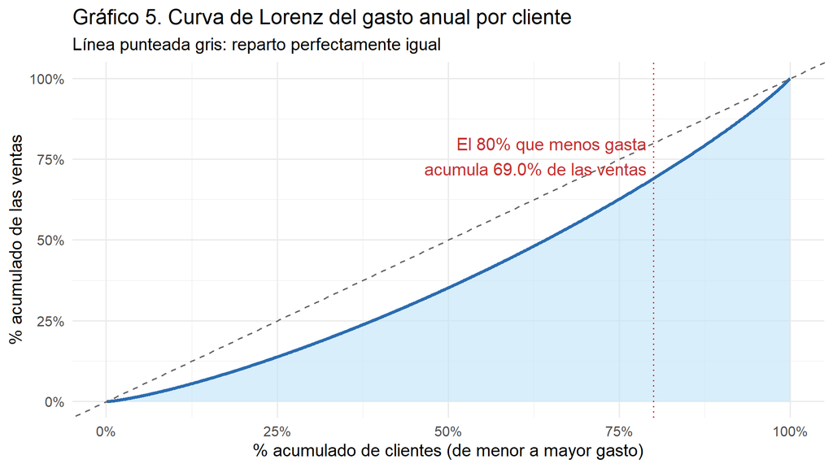

```r
lorenz <- cli %>% arrange(gasto) %>%
  mutate(pct_clientes = row_number() / n(), pct_ventas = cumsum(gasto) / sum(gasto)) %>%
  filter(row_number() %% 100 == 0)
base80 <- lorenz %>% filter(abs(pct_clientes - 0.80) < 1e-9) %>% pull(pct_ventas)

ggplot(lorenz, aes(pct_clientes, pct_ventas)) +
  geom_area(fill = "#bee3f8", alpha = .6) +
  geom_line(color = azul, linewidth = 1.1) +
  geom_abline(slope = 1, intercept = 0, linetype = "dashed", color = "grey40") +
  geom_vline(xintercept = 0.8, color = rojo, linetype = "dotted") +
  annotate("text", x = 0.79, y = base80 + 0.07, hjust = 1, color = rojo,
           label = paste0("El 80% que menos gasta\nacumula ", percent(base80, 0.1), " de las ventas")) +
  scale_x_continuous(labels = percent) + scale_y_continuous(labels = percent) +
  labs(title = "Gráfico 5. Curva de Lorenz del gasto anual por cliente",
       subtitle = "Línea punteada gris: reparto perfectamente igual",
       x = "% acumulado de clientes (de menor a mayor gasto)", y = "% acumulado de las ventas")
```

> **Cómo leerlo.** La línea azul acumula las ventas de los clientes ordenados de menor a mayor gasto. Cuanto más se aleje hacia abajo de la diagonal gris, más concentradas están las ventas en pocos clientes.

## 5.1 Comparación de escenarios: clasificación actual vs. clasificación por gasto

```r
top_k <- function(k) sum(sort(cli$gasto, decreasing = TRUE)[1:k]) / ventas_totales
niv <- function(n) sum(cli$gasto[cli$nivel_actual %in% n]) / ventas_totales
k_p  <- sum(cli$nivel_actual == "Platinum")
k_gp <- sum(cli$nivel_actual %in% c("Gold", "Platinum"))

captura <- tribble(
  ~grupo,                       ~criterio,                             ~clientes, ~part_ventas,
  "Grupo de ~25% de clientes",  "Escenario 1: nivel Platinum",         k_p,       niv("Platinum"),
  "Grupo de ~25% de clientes",  "Escenario 2: top 25% por gasto",      k_p,       top_k(k_p),
  "Grupo de ~50% de clientes",  "Escenario 1: niveles Gold + Platinum", k_gp,     niv(c("Gold","Platinum")),
  "Grupo de ~50% de clientes",  "Escenario 2: top 50% por gasto",      k_gp,      top_k(k_gp))

captura %>% mutate(clientes = comma(clientes), part_ventas = percent(part_ventas, 0.1)) %>%
  kable(caption = "Ventas que concentra cada grupo de clientes según el criterio de clasificación")
```

Ventas que concentra cada grupo de clientes según el criterio de clasificación

| grupo | criterio | clientes | part_ventas |
| --- | --- | --- | --- |
| Grupo de ~25% de clientes | Escenario 1: nivel Platinum | 24,926 | 24.9% |
| Grupo de ~25% de clientes | Escenario 2: top 25% por gasto | 24,926 | 37.3% |
| Grupo de ~50% de clientes | Escenario 1: niveles Gold + Platinum | 50,010 | 50.0% |
| Grupo de ~50% de clientes | Escenario 2: top 50% por gasto | 50,010 | 64.8% |

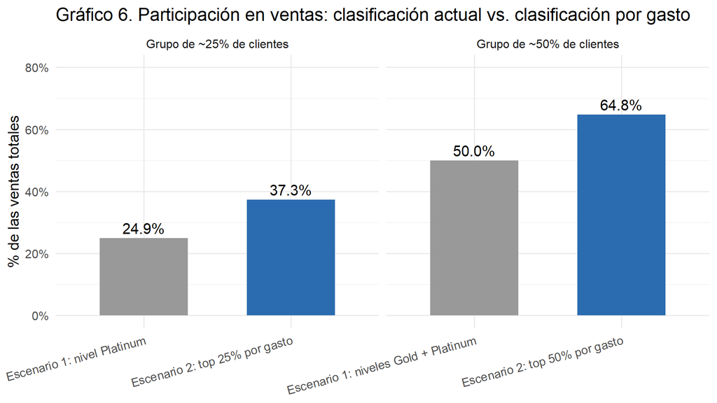

```r
ggplot(captura, aes(criterio, part_ventas, fill = str_detect(criterio, "Escenario 2"))) +
  geom_col(show.legend = FALSE, width = .6) +
  geom_text(aes(label = percent(part_ventas, 0.1)), vjust = -0.4) +
  facet_wrap(~ grupo, scales = "free_x") +
  scale_fill_manual(values = c("grey60", azul)) +
  scale_y_continuous(labels = percent, limits = c(0, 0.8)) +
  labs(title = "Gráfico 6. Participación en ventas: clasificación actual vs. clasificación por gasto",
       x = NULL, y = "% de las ventas totales") +
  theme(axis.text.x = element_text(angle = 15, hjust = 1))
```

> **Cómo leerlo.** Para un mismo número de clientes, se compara cuánto de las ventas concentra el grupo elegido por nivel (gris) contra el elegido por gasto (azul).

> **Qué significa para Elite Retail.** El nivel Platinum (25% de los clientes) concentra **24.9%** de las ventas, exactamente lo que le tocaría por tamaño: no destaca. El 25% que más gasta concentra **37.3%**, y el 50% que más gasta, **64.8%** (frente a 50.0% de Gold + Platinum). La clasificación por gasto es claramente más informativa **para describir el año 2025**.

> **Ojo con esta lectura:** esta ventaja es en parte automática, porque ordenar por gasto de un periodo siempre captura más gasto *de ese periodo*. La verdadera prueba de utilidad hacia adelante es la del Gráfico 4, y ahí no hay persistencia. Las dos cosas deben leerse juntas.

## 5.2 Clasificación propuesta (Objetivo 4)

Se propone reemplazar los niveles actuales por **cuatro niveles basados en el gasto anual** (percentiles), que incluyen el 20% de mayor valor definido en el objetivo SMART.

```r
cli <- cli %>% mutate(
  pos = rank(-gasto, ties.method = "first") / n(),
  nivel_propuesto = cut(pos, breaks = c(0, .2, .5, .8, 1), include.lowest = TRUE,
                        labels = c("A. Alto valor (top 20%)", "B. Valor medio-alto (20%-50%)",
                                   "C. Valor medio-bajo (50%-80%)", "D. Bajo valor (80%-100%)")))

perfil <- cli %>% group_by(nivel_propuesto) %>%
  summarise(clientes = n(), gasto_desde = min(gasto), gasto_hasta = max(gasto),
            gasto_medio = mean(gasto), compras_medias = mean(compras),
            ticket_medio = mean(ticket, na.rm = TRUE), ventas = sum(gasto), .groups = "drop") %>%
  mutate(pct_clientes = clientes / sum(clientes), pct_ventas = ventas / sum(ventas))

perfil %>% transmute(nivel = nivel_propuesto, clientes = comma(clientes),
                     `gasto anual desde` = comma(gasto_desde, 1), `hasta` = comma(gasto_hasta, 1),
                     `gasto medio` = comma(gasto_medio, 1), `compras al año` = round(compras_medias, 1),
                     `gasto por compra` = comma(ticket_medio, 1),
                     `% de las ventas` = percent(pct_ventas, 0.1)) %>%
  kable(caption = "Perfil de los niveles propuestos")
```

Perfil de los niveles propuestos

| nivel | clientes | gasto anual desde | hasta | gasto medio | compras al año | gasto por compra | % de las ventas |
| --- | --- | --- | --- | --- | --- | --- | --- |
| A. Alto valor (top 20%) | 20,000 | 112,609 | 281,963 | 133,778 | 13.9 | 9,798 | 31.0% |
| B. Valor medio-alto (20%-50%) | 30,000 | 83,713 | 112,608 | 97,097 | 11.0 | 9,048 | 33.8% |
| C. Valor medio-bajo (50%-80%) | 30,000 | 58,508 | 83,713 | 71,527 | 8.8 | 8,351 | 24.9% |
| D. Bajo valor (80%-100%) | 20,000 | 0 | 58,508 | 44,364 | 6.4 | 7,218 | 10.3% |

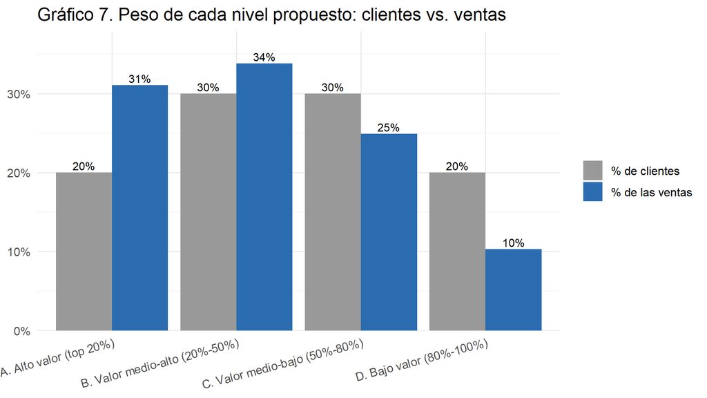

```r
perfil %>% select(nivel_propuesto, pct_clientes, pct_ventas) %>%
  pivot_longer(-nivel_propuesto, names_to = "medida", values_to = "valor") %>%
  mutate(medida = recode(medida, pct_clientes = "% de clientes", pct_ventas = "% de las ventas")) %>%
  ggplot(aes(nivel_propuesto, valor, fill = medida)) +
  geom_col(position = "dodge") +
  geom_text(aes(label = percent(valor, 1)), position = position_dodge(.9), vjust = -0.3, size = 3.2) +
  scale_y_continuous(labels = percent, expand = expansion(mult = c(0, .12))) +
  scale_fill_manual(values = c("grey60", azul)) +
  labs(title = "Gráfico 7. Peso de cada nivel propuesto: clientes vs. ventas",
       x = NULL, y = NULL, fill = NULL) +
  theme(axis.text.x = element_text(angle = 15, hjust = 1))
```

```r
table(Propuesto = cli$nivel_propuesto, Actual = cli$nivel_actual) %>% prop.table(1) %>% round(3)
```

```
##                                Actual
## Propuesto                       Bronze Silver  Gold Platinum
##   A. Alto valor (top 20%)        0.248  0.252 0.252    0.247
##   B. Valor medio-alto (20%-50%)  0.250  0.250 0.250    0.250
##   C. Valor medio-bajo (50%-80%)  0.249  0.250 0.253    0.248
##   D. Bajo valor (80%-100%)       0.251  0.249 0.248    0.252
```

```r
# Qué distingue al top 20%: más compras o compras más grandes
cli %>% group_by(grupo = ifelse(top20, "Top 20%", "Resto")) %>%
  summarise(compras = mean(compras), ticket = mean(ticket, na.rm = TRUE), unidades = mean(unidades)) %>%
  kable(digits = 1, caption = "¿Qué distingue al 20% de mayor gasto?")
```

¿Qué distingue al 20% de mayor gasto?

| grupo | compras | ticket | unidades |
| --- | --- | --- | --- |
| Resto | 9.0 | 8329.4 | 91.7 |
| Top 20% | 13.9 | 9798.2 | 158.8 |

```r
dir.create("salidas", showWarnings = FALSE)
cli %>% select(customer_id, nivel_actual, gasto, compras, nivel_propuesto, top20) %>%
  write_csv("salidas/clientes_clasificados.csv")
```

> **Cómo leerlo.** El Gráfico 7 compara qué parte de los clientes y qué parte de las ventas tiene cada nivel propuesto. La tabla indica el rango de gasto que define a cada nivel y cómo se comportan sus clientes.

# 6 Conclusiones y recomendaciones

**Respuesta a los objetivos de la Fase 1**

1. **Gasto anual (Obj. 1).** El cliente típico gasta ≈ 84,000 al año (media 86,200); las ventas de 2025 suman ≈ 8,622 millones.
2. **Niveles actuales (Obj. 2, Método 1).** **No hay diferencias de gasto entre Bronze, Silver, Gold y Platinum** (ANOVA p = 0.70; eta² ≈ 0). Tampoco en número de compras ni en gasto por compra.
3. **Top 20% (Obj. 3, Método 3).** El 20% de mayor gasto (20,000 clientes) aporta **31.0% de las ventas** (IC 95%: 31.0%–31.1%), coherente con la línea base. La concentración es baja (Gini = 0.21).
4. **Clasificación (Obj. 4, Métodos 2 y 3).** Los niveles actuales **no identifican** a los clientes de alto gasto (chi-cuadrado p = 0.79). Se propone una clasificación por gasto en cuatro niveles (A, B, C, D).

**Hallazgo clave y su implicación.** El Método 2 muestra que **el alto gasto no es persistente**: ser del 20% que más gasta en un semestre no aumenta la probabilidad de serlo en el siguiente (19.8% frente a 20.0%). Por eso se recomienda:

- **Usar la clasificación por gasto como una medición descriptiva del periodo, y recalcularla periódicamente** (por ejemplo, trimestral o con una ventana móvil de 12 meses), en lugar de asignar un nivel fijo para todo un año.
- **Vincular los beneficios al gasto efectivamente realizado**: por ejemplo, recompensas por alcanzar umbrales de gasto o de número de compras (la frecuencia es el principal diferenciador del Nivel A).
- **No concentrar todos los beneficios en el 20% superior:** aporta 31% de las ventas, mientras que el Nivel B aporta 34%.
- **Validar antes de implementar** con más de un año de historia y con información de costos de las recompensas, que hoy no está disponible (Fase 1, sección 3.2).

**Limitaciones**

- Los datos parecen sintéticos: las conclusiones son del conjunto de datos académico, no de una empresa real.
- El importe de venta se calcula con el precio de lista del catálogo (la tabla de ventas no trae precio).
- Se analiza un solo año; la persistencia solo se pudo probar entre dos semestres de 2025.
- No se dispone del costo de los beneficios, por lo que no se estima su rentabilidad.
- Los resultados muestran asociaciones y no causas.

# 7 Entorno